# R Project 2

## Summarizations

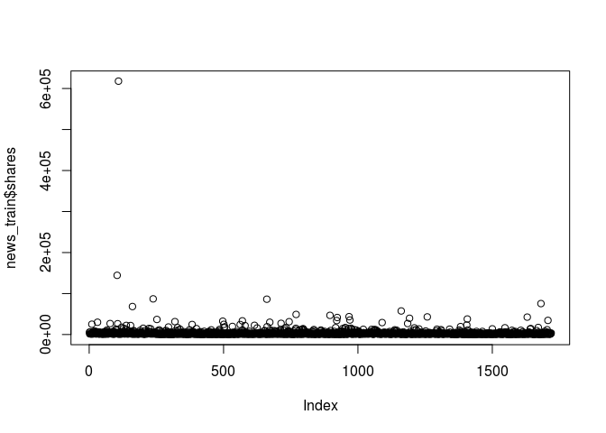

```r
# plot a visual of shares per article
plot(news_train$shares)
```

From the above plot, we can see any outliers. These could be affected by things beyond the variables we are observing in this model.

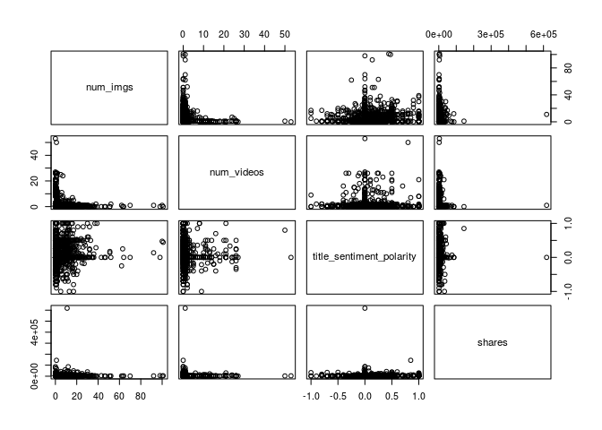

```r
# correlation plots of the variables selected
pairs(news_train[,2:5])
```

From the above plot, we can see any potential trends between the selected variables.

```r
# summary statistics of the variables selected
mean(news_train$shares)
```

```
## [1] 4183.119
```

```r
median(news_train$shares)
```

```
## [1] 2000
```

```r
sd(news_train$shares)
```

```
## [1] 16449.33
```

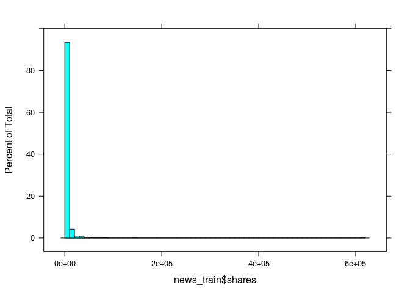

```r
histogram(news_train$shares, breaks=50)
```

A histogram displaying the spread of our response variable can be seen above.

## Modeling

```r
# create a non-ensemble tree model chosen using leave one out cross-validation
news_tree <- train(shares ~ .,
                   data=news_train,
                   method='rpart',
                   metric='MAE',
                   tuneLength=10,
                   trControl=trainControl(method='LOOCV'),
                   control=rpart.control(minsplit=1, minbucket=1)
                   )

# print out the results from our model selection
print(news_tree)
```

```
## CART
##
## 1719 samples
##    5 predictors
##
## No pre-processing
## Resampling: Leave-One-Out Cross-Validation
## Summary of sample sizes: 1718, 1718, 1718, 1718, 1718, 1718, ...
## Resampling results across tuning parameters:
##
##   cp            RMSE      Rsquared      MAE
##   0.0006293613  18348.70  7.160615e-05  3890.530
##   0.0006469420  18353.06  7.029192e-05  3901.234
##   0.0007841736  18314.01  7.010995e-05  3878.184
##   0.0008098509  18314.93  6.768081e-05  3883.522
##   0.0009462562  18295.19  7.963384e-05  3868.166
##   0.0012528980  18083.79  9.581822e-05  3807.889
##   0.0015785040  18003.69  7.630811e-05  3757.510
##   0.0038323665  17512.76  4.886350e-05  3726.722
##   0.0043975905  17500.02  7.717273e-06  3720.113
##   0.0388143365  16486.11  6.106663e-04  3521.249
##
## MAE was used to select the optimal model using the smallest value.
## The final value used for the model was cp = 0.03881434.
```

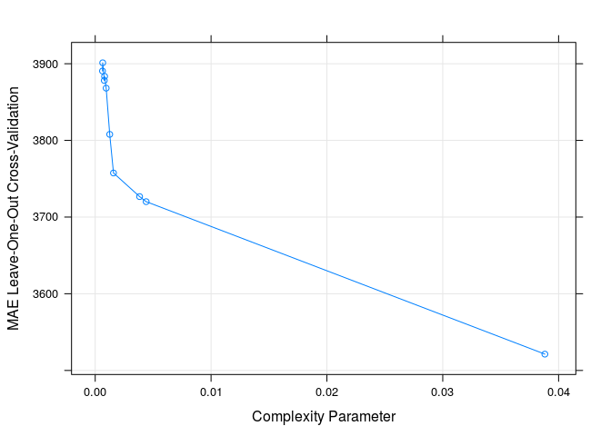

```r
# display a plot of the complexity values
plot(news_tree)
```

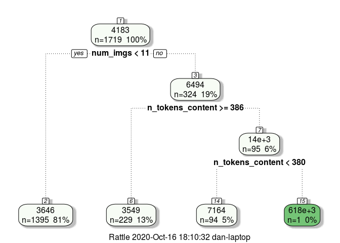

```r
# display a plot of the final tree model
fancyRpartPlot(news_tree$finalModel)
```

```r
# compare model to the test set
tree_pred <- predict(news_tree, newdata=news_test)
postResample(tree_pred, news_test$shares)
```

```
##         RMSE     Rsquared          MAE
## 2.366707e+04 7.385844e-05 3.925325e+03
```

Above we are fitting a tree-based model using leave one out cross validation. This is a regression tree, meaning we are trying to model a continuous response as opposed to classifying group membership. To fit this, for every possible value of each predictor, the MAE is found and minimized.

A potential issue with a tree-based method is that it can overfit our data, resulting in poorer performance when predicting on new data. This can be improved by pruning and cross-validation.

From the last output, we can see the mean absolute error (MAE). Because both models are using MAE as a means of optimization, we will compare this value to that received from boosting.

```r
# create a boosted tree model using cross-validation
boosted_tree <- train(shares ~ .,
                    data=news_train,
                    method='gbm',
                    metric='MAE',
                    tuneLength=10,
                    trControl=trainControl(method='repeatedcv', number=10, repeats=3)
                    )
```

```r
# print out the results from our model selection
print(boosted_tree)
```

```
## Stochastic Gradient Boosting
##
## 1719 samples
##    5 predictors
##
## No pre-processing
## Resampling: Cross-Validated (10 fold, repeated 3 times)
## Summary of sample sizes: 1547, 1550, 1548, 1548, 1547, 1546, ...
## Resampling results across tuning parameters:
##
##   interaction.depth  n.trees  RMSE      Rsquared     MAE
##    1                  50      10798.47  0.017188255  3656.636
##    1                 100      10836.02  0.015278881  3680.581
##    1                 150      10848.00  0.014443810  3677.596
##    1                 200      10870.91  0.013097106  3703.606
```

[output cut: 103 more lines]

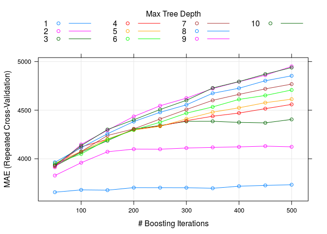

```r
# display a plot of the complexity values
plot(boosted_tree)
```

```r
# compare model to the test set
boosted_pred <- predict(boosted_tree, newdata=news_test)
postResample(boosted_pred, news_test$shares)
```

```
##         RMSE     Rsquared          MAE
## 6.569270e+03 1.301612e-02 3.387300e+03
```

A boosted tree model is an ensemble method, meaning it uses multiple learning algorithms to attempt to gain better performance than an individual model. The above model output and plot show the number of trees used in the final model and the tree depth.

This model performs better than the single tree-based model above in terms of out parameter of interest, MAE. This is likely due to a combination of the fact that the second model is using an ensemble method that fits more slowly, and the fact that singular tree-based models have a tendency to overfit their data, thus affecting the overall prediction value.